# Tratamiento de valores perdidos con conjunto de datos Titanic

Juan Gómez Romero

Tratamiento de valores perdidos con el dataset [titanic](https://www.kaggle.com/c/titanic/).

**En este cuaderno ampliaremos el código desarrollado en titanic.Rmd para tratar los valores perdidos de formas más sofisticadas.**

Internamente, [`rpart`](https://cran.r-project.org/web/packages/rpart/vignettes/longintro.pdf) utiliza un procedimiento para estimar los valores perdidos. Otras técnicas se limitan a omitir las filas con valores perdidos, lo que significa perder muchos datos significativos. Es conveniente por tanto gestionar los valores perdidos de una forma más controlada.

**Índice**

- 1. MissingDataGUI
- 2. VIM
- 3. MICE
- 4. NoiseFiltersR

# 0. Preprocesamiento de datos

Comenzamos leyendo el fichero de datos:

```r
library(tidyverse)
data_raw <- read_csv('train.csv')
head(data_raw)
```

```
## # A tibble: 6 x 12
##   PassengerId Survived Pclass Name  Sex     Age SibSp Parch Ticket  Fare
##         <dbl>    <dbl>  <dbl> <chr> <chr> <dbl> <dbl> <dbl> <chr>  <dbl>
## 1           1        0      3 Brau… male     22     1     0 A/5 2…  7.25
## 2           2        1      1 Cumi… fema…    38     1     0 PC 17… 71.3
## 3           3        1      3 Heik… fema…    26     0     0 STON/…  7.92
## 4           4        1      1 Futr… fema…    35     1     0 113803 53.1
## 5           5        0      3 Alle… male     35     0     0 373450  8.05
## 6           6        0      3 Mora… male     NA     0     0 330877  8.46
## # … with 2 more variables: Cabin <chr>, Embarked <chr>
```

# 1. MissingDataGUI

MissingDataGUI es una herramienta para explorar y reparar valores perdidos. Si bien su interfaz gráfica puede facilitar la gestión, la falta de documentación la hacen difícil de utilizar.

```r
# library(MissingDataGUI)
# if (interactive()) {
#        MissingDataGUI()
# }
```

# 2. VIM

[VIM](https://cran.r-project.org/web/packages/VIM/index.html) facilita la visualización de la distribución de los valores perdidos. Puede utilizarse en combinación con [`funModeling`](https://livebook.datascienceheroes.com/exploratory-data-analysis.html#dataset-health-status).

```r
# library(VIM)
# aggr(data_raw, col=c('navyblue','red'), numbers=TRUE, sortVars=TRUE, labels=names(data_raw), cex.axis=.7, gap=3, ylab=c("Histogram of missing data", "Pattern"))
```

# 3. MICE

[MICE](https://stefvanbuuren.name/mice/) es una de las bibliotecas más completas para realizar imputación de valores perdidos.

En el conjunto de datos existen valores perdidos en: ‘Cabin’, ‘Age’, ‘Embarked’. Con [MICE](https://stefvanbuuren.name/mice/) podemos crear un modelo de imputación que emplee [diferentes técnicas de imputación](https://www.rdocumentation.org/packages/mice/versions/3.7.0/topics/mice) para cada columna. Con [`complete`](https://www.rdocumentation.org/packages/mice/versions/3.7.0/topics/complete) obtenemos el resultado de la imputación de acuerdo al modelo generado.

```r
library(mice)
imputation <- mice(data_raw, method = c("", "", "", "", "", "mean", "", "", "", "", "cart", "cart"))
imputation
```

```
## Class: mids
## Number of multiple imputations:  5
## Imputation methods:
## PassengerId    Survived      Pclass        Name         Sex         Age
##          ""          ""          ""          ""          ""      "mean"
##       SibSp       Parch      Ticket        Fare       Cabin    Embarked
##          ""          ""          ""          ""          ""          ""
## PredictorMatrix:
##             PassengerId Survived Pclass Name Sex Age SibSp Parch Ticket
## PassengerId           0        1      1    0   0   1     1     1      0
## Survived              1        0      1    0   0   1     1     1      0
## Pclass                1        1      0    0   0   1     1     1      0
## Name                  1        1      1    0   0   1     1     1      0
## Sex                   1        1      1    0   0   1     1     1      0
## Age                   1        1      1    0   0   0     1     1      0
##             Fare Cabin Embarked
## PassengerId    1     0        0
## Survived       1     0        0
## Pclass         1     0        0
## Name           1     0        0
## Sex            1     0        0
## Age            1     0        0
## Number of logged events:  5
##   it im dep     meth      out
## 1  0  0     constant     Name
## 2  0  0     constant      Sex
## 3  0  0     constant   Ticket
## 4  0  0     constant    Cabin
## 5  0  0     constant Embarked
```

```r
head(complete(imputation))
```

```
##   PassengerId Survived Pclass
## 1           1        0      3
## 2           2        1      1
## 3           3        1      3
## 4           4        1      1
## 5           5        0      3
## 6           6        0      3
##                                                  Name    Sex      Age
## 1                             Braund, Mr. Owen Harris   male 22.00000
## 2 Cumings, Mrs. John Bradley (Florence Briggs Thayer) female 38.00000
## 3                              Heikkinen, Miss. Laina female 26.00000
## 4        Futrelle, Mrs. Jacques Heath (Lily May Peel) female 35.00000
## 5                            Allen, Mr. William Henry   male 35.00000
## 6                                    Moran, Mr. James   male 29.69912
##   SibSp Parch           Ticket    Fare Cabin Embarked
## 1     1     0        A/5 21171  7.2500  <NA>        S
## 2     1     0         PC 17599 71.2833   C85        C
## 3     0     0 STON/O2. 3101282  7.9250  <NA>        S
## 4     1     0           113803 53.1000  C123        S
## 5     0     0           373450  8.0500  <NA>        S
## 6     0     0           330877  8.4583  <NA>        Q
```

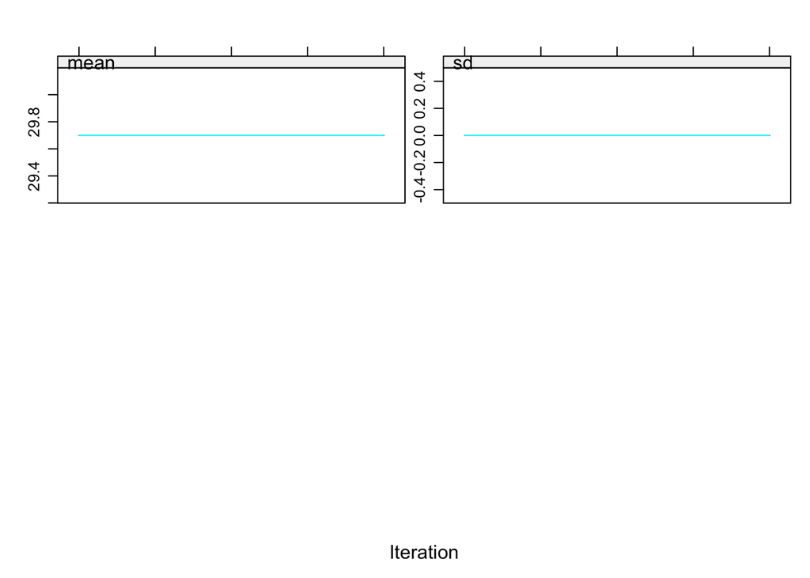

```r
plot(imputation)
```

[figure not shown]

```r
stripplot(imputation, pch = 20, cex = 1.2)
```

Podemos combinar `mice` y [`caret`](http://topepo.github.io/caret/) para crear manualmente modelos de predicción con varias imputaciones:

```r
library(caret)
# Particiones de datos y parametros generales
trainIndex <- createDataPartition(data_raw$Survived, p = .8, list = FALSE, times = 1)
rpartCtrl <- trainControl(verboseIter = F, classProbs = TRUE, summaryFunction = twoClassSummary)
rpartParametersGrid <- expand.grid(.cp = c(0.01, 0.05))

# Imputación resultado
data_raw_imputation_1 <-
  complete(imputation) %>%
  mutate(Survived = as.factor(ifelse(Survived == 1, 'Yes', 'No'))) %>%
  mutate(Pclass = as.factor(Pclass)) %>%
  mutate(Fare_Interval = as.factor(
    case_when(
      Fare >= 30 ~ 'More.than.30',
      Fare >= 20 & Fare < 30 ~ 'Between.20.30',
      Fare < 20 & Fare >= 10 ~ 'Between.10.20',
      Fare < 10 ~ 'Less.than.10'))) %>%
  select(Survived, Age, Pclass, Sex, Fare_Interval)

# Entrenar modelo 1
train   <- data_raw_imputation_1[ trainIndex, ]
val     <- data_raw_imputation_1[-trainIndex, ]
rPartModel_1 <- train(Survived ~ Age + Pclass + Sex + Fare_Interval, data = data_raw_imputation_1, method = "rpart", metric = "ROC", trControl = rpartCtrl, tuneGrid = rpartParametersGrid)

## Imputación alternativa
data_raw_imputation_2 <-
  complete(imputation, 2) %>%  # se selecciona la alternativa 2 de imputación
  mutate(Survived = as.factor(ifelse(Survived == 1, 'Yes', 'No'))) %>%
  mutate(Pclass = as.factor(Pclass)) %>%
  mutate(Fare_Interval = as.factor(
    case_when(
      Fare >= 30 ~ 'More.than.30',
      Fare >= 20 & Fare < 30 ~ 'Between.20.30',
      Fare < 20 & Fare >= 10 ~ 'Between.10.20',
      Fare < 10 ~ 'Less.than.10'))) %>%
  select(Survived, Age, Pclass, Sex, Fare_Interval)

# Entrenar modelo 2
train   <- data_raw_imputation_2[ trainIndex, ]
val     <- data_raw_imputation_2[-trainIndex, ]
rPartModel_2 <- train(Survived ~ Age + Pclass + Sex + Fare_Interval, data = data_raw_imputation_2, method = "rpart", metric = "ROC", trControl = rpartCtrl, tuneGrid = rpartParametersGrid)
```

Y después seleccionar el que mejor ha funcionado, en entrenamiento o validación. (En este caso no hay diferencias porque ambas imputaciones son idénticas.)

```r
# Comparación
prediction_1 <- predict(rPartModel_1, val, type = "raw")
(cm_train_1 <- confusionMatrix(prediction_1, val[["Survived"]]))
```

```
## Confusion Matrix and Statistics
##
##           Reference
## Prediction No Yes
##        No  97  27
##        Yes 12  42
##
##                Accuracy : 0.7809
##                  95% CI : (0.7129, 0.8393)
##     No Information Rate : 0.6124
##     P-Value [Acc > NIR] : 1.227e-06
##
##                   Kappa : 0.5193
##  Mcnemar's Test P-Value : 0.02497
##
##             Sensitivity : 0.8899
##             Specificity : 0.6087
##          Pos Pred Value : 0.7823
##          Neg Pred Value : 0.7778
##              Prevalence : 0.6124
##          Detection Rate : 0.5449
##    Detection Prevalence : 0.6966
##       Balanced Accuracy : 0.7493
##
##        'Positive' Class : No
##
```

```r
prediction_2 <- predict(rPartModel_2, val, type = "raw")
(cm_train_2 <- confusionMatrix(prediction_2, val[["Survived"]]))
```

```
## Confusion Matrix and Statistics
##
##           Reference
## Prediction No Yes
##        No  97  27
##        Yes 12  42
##
##                Accuracy : 0.7809
##                  95% CI : (0.7129, 0.8393)
##     No Information Rate : 0.6124
##     P-Value [Acc > NIR] : 1.227e-06
##
##                   Kappa : 0.5193
##  Mcnemar's Test P-Value : 0.02497
##
##             Sensitivity : 0.8899
##             Specificity : 0.6087
##          Pos Pred Value : 0.7823
##          Neg Pred Value : 0.7778
##              Prevalence : 0.6124
##          Detection Rate : 0.5449
##    Detection Prevalence : 0.6966
##       Balanced Accuracy : 0.7493
##
##        'Positive' Class : No
##
```

# 4. NoiseFiltersR

Para gestionar valores con ruido, utilizamos las herramientas incluidas en [`NoiseFiltersR`](https://cran.r-project.org/web/packages/NoiseFiltersR/index.html).

```r
# Instalar RWeka (http://stackoverflow.com/a/36173681)
library(NoiseFiltersR)
data <- data_raw %>%
  mutate(Survived = as.factor(Survived)) %>%
  mutate(Pclass = as.factor(Pclass))   %>%
  mutate(Age = as.factor(Age))      %>%
  mutate(Sex = as.factor(Sex))      %>%
  select(Pclass, Survived, Age, Sex)

noise_filter <- AENN(Survived ~., data)
summary(noise_filter)
```

```
## Filter AENN applied to dataset data
##
## Call:
## AENN(formula = Survived ~ ., data = data)
##
## Parameters:
## k: 5
##
## Results:
## Number of removed instances: 294 (32.99663 %)
## Number of repaired instances: 0 (0 %)
```

```r
identical(noise_filter$cleanData, data[setdiff(1:nrow(data), noise_filter$remIdx), ])
```

```
## [1] TRUE
```